# Aula 01 Oscilador Harmonico

## 1) Oscilador harmônico

A equação do movimento é dada por:

$$ F = m \ddot{x} $$

Para a mola:

$$ F = -kx \quad \Rightarrow \quad -kx = m \ddot{x} $$

## Solução geral

$$ x(t) = a \cos(\omega t) + b \sin(\omega t) $$

Ou, de forma equivalente,

$$ x(t) = A \cos(\omega t + \psi) $$

## Onde:

$$ a = A \cos \psi $$

$$ b = -A \sin \psi $$

$$ A = \sqrt{a^2 + b^2} $$

$$ \cos \psi = \frac{a}{\sqrt{a^2 + b^2}} $$

$$ \sin \psi = \frac{-b}{\sqrt{a^2 + b^2}} $$

## Frequência angular

$$ \omega^2 = \frac{k}{m} $$

## Interpretação física dos parâmetros

### (i) Amplitude

$$ A $$

É a amplitude de oscilação, que é igual a:

$$ A = |x(t)|_{\text{max}} $$

### (ii) Período de oscilação

O período de oscilação $T$ é dado por:

$$ T = \frac{2\pi}{\omega} $$

A frequência é:

$$ f = \frac{1}{T} $$

Substituindo:

$$ T = 2\pi \sqrt{\frac{m}{k}} $$

$$ f = \frac{1}{2\pi} \sqrt{\frac{k}{m}} $$

## Observação sobre frequência

- $f$ é a frequência de oscilação, medida em Hz
- A grandeza

$$ \omega = 2\pi f $$

chama-se frequência angular

- $\omega$ é medida em rad/s ou $s^{-1}$

## Gráfico ilustrativo do oscilador harmônico

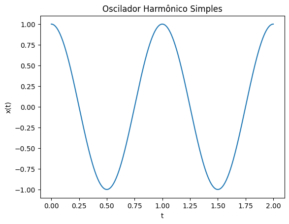

```python
import numpy as np
import matplotlib.pyplot as plt

A = 1.0
omega = 2*np.pi
psi = 0.0

t = np.linspace(0, 2, 500)
x = A * np.cos(omega * t + psi)

plt.figure()
plt.plot(t, x)
plt.xlabel("t")
plt.ylabel("x(t)")
plt.title("Oscilador Harmônico Simples")
plt.show()
```

## Fase do movimento

O argumento do cosseno $(\theta = \omega t + \psi)$ chama-se **fase do movimento**.  
$\psi$ é a **constante de fase** ou **fase inicial** (valor da fase para $t = 0$).

## Ajuste das condições iniciais

Derivando a equação da posição:

$$ x(t) = A \cos(\omega t + \psi) $$

Temos:

$$ \dot{x}(t) = v(t) = -\omega A \sin(\omega t + \psi) $$

De modo que, para satisfazer as condições iniciais, temos:

$$ x_0 = A \cos \psi $$

e

$$ v_0 = -\omega A \sin \psi $$

Podemos com isso escrever:

$$ x(t) = x_0 \cos(\omega t) + \frac{v_0}{\omega} \sin(\omega t) $$

Também podemos determinar $A$ e $\psi$ com isso:

$$ A = \sqrt{x_0^2 + \frac{v_0^2}{\omega^2}} $$

$$ \cos \psi = \frac{x_0}{A} $$

$$ \sin \psi = -\frac{v_0}{\omega A} $$

$$ \tan \psi = -\frac{v_0}{\omega x_0} $$

## Relação entre posição e velocidade

Comparando a equação da posição com a da velocidade, notamos que a velocidade do oscilador está **adiantada de $\pi/2$** em relação ao deslocamento, ou seja, está em **quadratura** com ele.

Quando $|x| = A$ (deslocamento máximo), a velocidade é nula.  
Esses pontos são chamados de **pontos de inversão**.

## Gráfico: posição e velocidade em função do tempo

```
Matplotlib is building the font cache; this may take a moment.
```

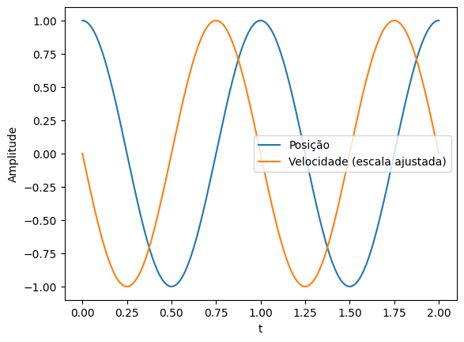

```python
import numpy as np
import matplotlib.pyplot as plt

A = 1.0
omega = 2*np.pi
psi = 0.0

t = np.linspace(0, 2, 500)

x = A * np.cos(omega*t + psi)
v = -omega * A * np.sin(omega*t + psi)

plt.figure()
plt.plot(t, x, label="Posição")
plt.plot(t, v/omega, label="Velocidade (escala ajustada)")
plt.xlabel("t")
plt.ylabel("Amplitude")
plt.legend()
plt.show()
```

## Energia do oscilador

$$ K(t) = \frac{m \dot{x}^2(t)}{2} = \frac{1}{2} m \omega^2 A^2 \sin^2(\omega t + \psi) $$

$$ U(t) = \frac{k x^2(t)}{2} = \frac{1}{2} m \omega^2 A^2 \cos^2(\omega t + \psi) $$

Onde: • $K$ é a energia cinética • $U$ é a energia potencial

Somando membro a membro, obtemos a energia total $(E)$, que se conserva:

$$ E = K + U = \frac{1}{2} m \omega^2 A^2 $$

Interpretação energética

Nos instantes em que o oscilador passa pela posição de equilíbrio, a energia é puramente cinética. Nos pontos extremos, a energia é puramente potencial.

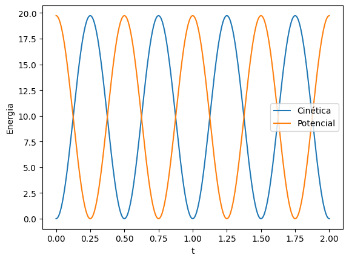

```python
K = 0.5 * (omega*A*np.sin(omega*t))**2
U = 0.5 * (omega*A*np.cos(omega*t))**2

plt.figure()
plt.plot(t, K, label="Cinética")
plt.plot(t, U, label="Potencial")
plt.xlabel("t")
plt.ylabel("Energia")
plt.legend()
plt.show()
```

Exemplo: pêndulo • Extremos do movimento: totalmente potencial $(U)$ • Passagem pelo equilíbrio: totalmente cinética $(K)$

# Exemplos e aplicações

## a) O pêndulo de torção

Consideremos uma barra horizontal suspensa em equilíbrio por um fio vertical.  
Se defletirmos (movermos) a barra no plano horizontal de um pequeno ângulo em relação à posição de equilíbrio, a lei de Hooke para a torção do fio diz que ele reage com um torque restaurador proporcional ao ângulo de torção:

$$ \tau = -k \, \phi $$

$k$ é o módulo de torção, que depende do seu diâmetro, comprimento e material.

Analisando a fórmula do torque $(\tau = I \alpha)$, temos:

$$ I \ddot{\phi} = -k \phi $$

ou

$$ \ddot{\phi} + \omega^2 \phi = 0 $$

onde

$$ \omega^2 = \frac{k}{I} $$

## b) O pêndulo simples

A equação do movimento angular é:

$$ m a_\theta = m l \frac{d^2 \theta}{dt^2} = - m g \sin \theta $$

Logo,

$$ \frac{d^2 \theta}{dt^2} = -\frac{g}{l} \sin \theta $$

Lembrando que $a_\theta = a_R$.

Aproximando $\sin \theta \approx \theta$, aproximação que só pode ser feita para pequenos ângulos, temos:

$$ \ddot{\theta} + \frac{g}{l} \theta = 0 $$

ou

$$ \ddot{\theta} + \omega^2 \theta = 0 $$

onde

$$ \omega^2 = \frac{g}{l} $$

O período para pequenas oscilações do pêndulo é:

$$ T = 2\pi \sqrt{\frac{l}{g}} $$

Obs.: $T$ é independente da amplitude de oscilação.

## Energia do pêndulo

A energia cinética é:

$$ K(t) = \frac{1}{2} m v^2 = \frac{1}{2} m l^2 \dot{\theta}^2 $$

A energia potencial (caso geral) é:

$$ U(t) = m g l (1 - \cos \theta) $$

Para pequenos ângulos:

$$ U(t) = \frac{1}{2} m g l \theta^2 = \frac{1}{2} m \omega^2 l^2 \theta^2 $$

### Energia total

$$ E = \frac{1}{2} m l^2 \dot{\theta}^2 + m g l (1 - \cos \theta) $$

### Posições de equilíbrio

O pêndulo estará em equilíbrio estável quando $\theta = 0$  
e instável quando $\theta = \pi$.

## c) O pêndulo físico

O torque é dado por:

$$ \tau = - M g s \sin \theta $$

Logo,

$$ I \ddot{\theta} = - M g s \sin \theta $$

O momento de inércia pode ser escrito como:

$$ I = M k^2 $$

com

$$ k^2 = l s $$

e

$$ s_c = l - s $$

## d) Oscilações de um líquido em tubos em U

$p$ = densidade  
$A$ = seção transversal

A energia potencial é:

$$ U(y) = p A y \, g \, y = p A g y^2 $$

A energia cinética é:

$$ K(y) = \frac{1}{2} p A l \left(\frac{dy}{dt}\right)^2 $$

A energia total é:

$$ E = \frac{1}{2} p A l \dot{y}^2 + p A g y^2 $$

Comparando com a energia de um oscilador harmônico:

$$ \frac{1}{2} K = \frac{1}{2} M \omega^2 $$

com

$$ M = p A l $$

Temos:

$$ p A g = \frac{1}{2} p A l \omega^2 $$

Logo,

$$ \omega^2 = \frac{2g}{l} $$

Com isso é possível encontrar a frequência angular das oscilações harmônicas da massa líquida.

### Frase de Newton

> “Se a água sobe e desce alternadamente nos ramos de um pêndulo cujo comprimento entre o ponto de oscilação é igual à metade do comprimento da água no tubo, digo então que a água subirá e descerá nos mesmos tempos em que o pêndulo oscila.”

## e) Oscilações de duas partículas acopladas

$l$ = comprimento de equilíbrio da mola

Considerando:

$$ x = (x_2 - x_1) - l $$

Temos que:

$$ F_1 = K x = -F_2 $$

$$ m_1 \ddot{x}_1 = K x $$

$$ m_2 \ddot{x}_2 = -K x $$

o que leva a:

$$ \mu \ddot{x} = -K x $$

onde

$$ \mu = \frac{m_1 m_2}{m_1 + m_2} $$

A energia total pode ser escrita como:

$$ E = E_{CM} + E' $$

com

$$ E_{CM} = K_{CM} = \frac{M V^2}{2} $$

e

$$ E' = \frac{1}{2} \mu \dot{x}^2 + \frac{1}{2} K x^2 $$

A energia do centro de massa e a energia interna se conservam separadamente;  
a translação do CM não afeta a oscilação.